# Estuary Fish Survey: Data Cleaning, Integration and Visualisation

Author

Kendra Sturdee

Published

October 5, 2026

# Introduction

The goal of this exercise is to wrangle extremely messy data, and produce a final clean dataset and figure on the Ross River estuary fish surveys. The data are from a previous PhD student who conducted surveys over 30 days in May 2026 at four different sites along the Ross River estuary, Townsville, Queensland, Australia. The data include catch counts for four different fish species, as well as environmental data (temperature, salinity, and turbidity) collected at each site using sonde sensors.

## Packages and housekeeping

```r
#| message: true
#| warning: false
rm(list = ls())

library(tidyverse)
library(dplyr)
library(ggplot2)
library(lubridate)
library(readxl)
```

## Main dataset

The catch data is split across 4 tabs in one excel file Load. We must load them indivudally.

```r
catch1 <- read_excel(here::here("data/workshop2/estuary_catch_log.xlsx"), sheet = "Lower_ross")
catch2 <- read_excel("../data/workshop2/estuary_catch_log.xlsx", sheet = 2)
catch3 <- read_excel("../data/workshop2/estuary_catch_log.xlsx", sheet = 3)
catch4 <- read_excel("../data/workshop2/estuary_catch_log.xlsx", sheet = 4)
```

## Inspect individual tabs

Must inspect the data for missing values, discreptancies, and errors before we proceed.

```r
catch1
```

```
# A tibble: 104 × 4
   site       date                species       count
   <chr>      <dttm>              <chr>         <dbl>
 1 Lower_ross 2026-05-01 00:00:00 barramundi        6
 2 Lower_ross 2026-05-01 00:00:00 MANGROVE JACK     3
 3 Lower_ross 2026-05-01 00:00:00 bream             4
 4 Lower_ross 2026-05-01 00:00:00 flathead          2
 5 Lower_ross 2026-05-02 00:00:00 barramundi        1
 6 Lower_ross 2026-05-02 00:00:00 MANGROVE JACK     1
 7 Lower_ross 2026-05-02 00:00:00 bream             3
 8 Lower_ross 2026-05-02 00:00:00 flathead          3
 9 Lower_ross 2026-05-03 00:00:00 MANGROVE JACK     2
10 Lower_ross 2026-05-03 00:00:00 flathead          3
# ℹ 94 more rows
```

```r
catch2
```

```
# A tibble: 106 × 4
   site     date                species       count
   <chr>    <dttm>              <chr>         <dbl>
 1 Mid_Ross 2026-05-01 00:00:00 barramundi        4
 2 Mid_Ross 2026-05-01 00:00:00 MANGROVE JACK     2
 3 Mid_Ross 2026-05-01 00:00:00 bream             2
 4 Mid_Ross 2026-05-01 00:00:00 flathead          3
 5 Mid_Ross 2026-05-02 00:00:00 MANGROVE JACK     1
 6 Mid_Ross 2026-05-02 00:00:00 bream             2
 7 Mid_Ross 2026-05-02 00:00:00 flathead          3
 8 Mid_Ross 2026-05-03 00:00:00 barramundi        3
 9 Mid_Ross 2026-05-03 00:00:00 MANGROVE JACK     2
10 Mid_Ross 2026-05-03 00:00:00 bream             1
# ℹ 96 more rows
```

```r
catch3
```

```
# A tibble: 107 × 4
   site       date                species       count
   <chr>      <dttm>              <chr>         <dbl>
 1 ROSS MOUTH 2026-05-01 00:00:00 barramundi        3
 2 ROSS MOUTH 2026-05-01 00:00:00 MANGROVE JACK     2
 3 ROSS MOUTH 2026-05-01 00:00:00 flathead          9
 4 ROSS MOUTH 2026-05-02 00:00:00 MANGROVE JACK     1
 5 ROSS MOUTH 2026-05-02 00:00:00 bream             3
 6 ROSS MOUTH 2026-05-02 00:00:00 flathead          4
 7 ROSS MOUTH 2026-05-03 00:00:00 barramundi        1
 8 ROSS MOUTH 2026-05-03 00:00:00 MANGROVE JACK     1
 9 ROSS MOUTH 2026-05-03 00:00:00 bream             2
10 ROSS MOUTH 2026-05-03 00:00:00 flathead          7
# ℹ 97 more rows
```

```r
catch4
```

```
# A tibble: 110 × 4
   site       date                species       count
   <chr>      <dttm>              <chr>         <dbl>
 1 Upper Ross 2026-05-01 00:00:00 barramundi        5
 2 Upper Ross 2026-05-01 00:00:00 bream             2
 3 Upper Ross 2026-05-01 00:00:00 flathead          6
 4 Upper Ross 2026-05-02 00:00:00 barramundi        8
 5 Upper Ross 2026-05-02 00:00:00 MANGROVE JACK     1
 6 Upper Ross 2026-05-02 00:00:00 bream             2
 7 Upper Ross 2026-05-02 00:00:00 flathead          4
 8 Upper Ross 2026-05-03 00:00:00 barramundi        4
 9 Upper Ross 2026-05-03 00:00:00 bream             2
10 Upper Ross 2026-05-04 00:00:00 barramundi        5
# ℹ 100 more rows
```

```r
catch_data <- bind_rows(catch1, catch2, catch3, catch4)
# Clean up the environment
rm(catch1, catch2, catch3, catch4) # Clean up the environment
```

## Preliminary checks

```r
catch_data
```

```
# A tibble: 427 × 4
   site       date                species       count
   <chr>      <dttm>              <chr>         <dbl>
 1 Lower_ross 2026-05-01 00:00:00 barramundi        6
 2 Lower_ross 2026-05-01 00:00:00 MANGROVE JACK     3
 3 Lower_ross 2026-05-01 00:00:00 bream             4
 4 Lower_ross 2026-05-01 00:00:00 flathead          2
 5 Lower_ross 2026-05-02 00:00:00 barramundi        1
 6 Lower_ross 2026-05-02 00:00:00 MANGROVE JACK     1
 7 Lower_ross 2026-05-02 00:00:00 bream             3
 8 Lower_ross 2026-05-02 00:00:00 flathead          3
 9 Lower_ross 2026-05-03 00:00:00 MANGROVE JACK     2
10 Lower_ross 2026-05-03 00:00:00 flathead          3
# ℹ 417 more rows
```

```r
head(catch_data)
```

```
# A tibble: 6 × 4
  site       date                species       count
  <chr>      <dttm>              <chr>         <dbl>
1 Lower_ross 2026-05-01 00:00:00 barramundi        6
2 Lower_ross 2026-05-01 00:00:00 MANGROVE JACK     3
3 Lower_ross 2026-05-01 00:00:00 bream             4
4 Lower_ross 2026-05-01 00:00:00 flathead          2
5 Lower_ross 2026-05-02 00:00:00 barramundi        1
6 Lower_ross 2026-05-02 00:00:00 MANGROVE JACK     1
```

```r
glimpse(catch_data)
```

```
Rows: 427
Columns: 4
$ site    <chr> "Lower_ross", "Lower_ross", "Lower_ross", "Lower_ross", "Lower…
$ date    <dttm> 2026-05-01, 2026-05-01, 2026-05-01, 2026-05-01, 2026-05-02, 2…
$ species <chr> "barramundi", "MANGROVE JACK", "bream", "flathead", "barramund…
$ count   <dbl> 6, 3, 4, 2, 1, 1, 3, 3, 2, 3, 1, 8, 4, 1, 1, 2, 1, 2, 4, 2, 2,…
```

```r
str(catch_data)
```

```
tibble [427 × 4] (S3: tbl_df/tbl/data.frame)
 $ site   : chr [1:427] "Lower_ross" "Lower_ross" "Lower_ross" "Lower_ross" ...
 $ date   : POSIXct[1:427], format: "2026-05-01" "2026-05-01" ...
 $ species: chr [1:427] "barramundi" "MANGROVE JACK" "bream" "flathead" ...
 $ count  : num [1:427] 6 3 4 2 1 1 3 3 2 3 ...
```

From this inspection we cannot see how many sites and species we have in the dataset. We can check this by using distinct() or by converting to factors

```r
catch_data |>
  distinct(site)
```

```
# A tibble: 4 × 1
  site
  <chr>
1 Lower_ross
2 Mid_Ross
3 ROSS MOUTH
4 Upper Ross
```

```r
catch_data |>
  distinct(species)
```

```
# A tibble: 4 × 1
  species
  <chr>
1 barramundi
2 MANGROVE JACK
3 bream
4 flathead
```

Now I know I have four sites, and four species. By naming convention, I can infer that the sites are located along the Ross River estuary, but I need to check this against the metadata once I load it. The species names are also messy and will need to be cleaned before I can join with the taxonomic dictionary to get scientific names.

## Load metadata

```r
metadata <- read_csv("../data/workshop2/estuary_metadata.csv")
```

## Checks

```r
head(metadata)
```

```
# A tibble: 4 × 4
  site_name    lat   lon zone
  <chr>      <dbl> <dbl> <chr>
1 Upper_Ross -19.3  147. Upstream
2 mid_ross   -19.3  147. Middle
3 LOWER ROSS -19.3  147. Downstream
4 ross_mouth -19.2  147. Marine
```

```r
glimpse(metadata)
```

```
Rows: 4
Columns: 4
$ site_name <chr> "Upper_Ross", "mid_ross", "LOWER ROSS", "ross_mouth"
$ lat       <dbl> -19.31, -19.28, -19.26, -19.25
$ lon       <dbl> 146.74, 146.78, 146.81, 146.83
$ zone      <chr> "Upstream", "Middle", "Downstream", "Marine"
```

### Clean and standardised site names and convert character to factor variables

```r
catch_data <- catch_data |>
  mutate(
    site = str_to_lower(str_trim(site)),
    site = str_replace_all(site, " ", "_")) |>
  # Convert all chr to fct
  mutate(across(where(is.character), as_factor)
  )

metadata <- metadata |>
  mutate(
    site_name = str_to_lower(str_trim(site_name)),
    site_name = str_replace_all(site_name, " ", "_")) |>
  # Convert all chr to fct
  mutate(across(where(is.character), as_factor)
  )
```

## Sanity check

```r
catch_data |>
  str()
```

```
tibble [427 × 4] (S3: tbl_df/tbl/data.frame)
 $ site   : Factor w/ 4 levels "lower_ross","mid_ross",..: 1 1 1 1 1 1 1 1 1 1 ...
 $ date   : POSIXct[1:427], format: "2026-05-01" "2026-05-01" ...
 $ species: Factor w/ 4 levels "barramundi","MANGROVE JACK",..: 1 2 3 4 1 2 3 4 2 4 ...
 $ count  : num [1:427] 6 3 4 2 1 1 3 3 2 3 ...
```

```r
 catch_data |>
   distinct(site)
```

```
# A tibble: 4 × 1
  site
  <fct>
1 lower_ross
2 mid_ross
3 ross_mouth
4 upper_ross
```

```r
str(metadata)
```

```
tibble [4 × 4] (S3: tbl_df/tbl/data.frame)
 $ site_name: Factor w/ 4 levels "upper_ross","mid_ross",..: 1 2 3 4
 $ lat      : num [1:4] -19.3 -19.3 -19.3 -19.2
 $ lon      : num [1:4] 147 147 147 147
 $ zone     : Factor w/ 4 levels "Upstream","Middle",..: 1 2 3 4
```

OK site names fixed in both now (but note the vars themselves still have different names - site vs site_name). We can fix this when we join the datasets together. Next we need to do something about the species names. Can use the taxonomic dictionary to get scientific names for the species.

### Load Taxonomic Dictionary

```r
species_dict <- read_csv("../data/workshop2/species_dictionary.csv")
# Check
head(species_dict)
```

```
# A tibble: 4 × 2
  common_name   scientific_name
  <chr>         <chr>
1 barramundi    Lates calcarifer
2 mangrove_jack Lutjanus argentimaculatus
3 bream         Acanthopagrus spp.
4 flathead      Platycephalus spp.
```

Must reference common names in catch log to those in the taxonomic dictionary before we do a join.

```r
catch_data |>
  distinct(species)
```

```
# A tibble: 4 × 1
  species
  <fct>
1 barramundi
2 MANGROVE JACK
3 bream
4 flathead
```

```r
# Can see these are different to the dictionary
species_dict |>
  distinct(common_name)
```

```
# A tibble: 4 × 1
  common_name
  <chr>
1 barramundi
2 mangrove_jack
3 bream
4 flathead
```

Only difference is between mangrove_jack and MANGROVE JACK. We can fix this by standardising the species names in the catch log to match those in the dictionary.

### Standardise species (common name) variable in the catch log to match dictionary

```r
catch_data <- catch_data |>
  mutate(
    species = str_to_lower(str_trim(species)),
    species = str_replace_all(species, " ", "_")
  )
```

Still must create scientific_name variables

### Create new variable (“scientific_name”) in catch log by joining with taxonomic dictionary

```r
catch_data <- catch_data |>
  mutate(common_name = species) |>
  left_join(species_dict, by = join_by(common_name))
```

# Sanity check: site names + scientific names

```r
glimpse(catch_data)
```

```
Rows: 427
Columns: 6
$ site            <fct> lower_ross, lower_ross, lower_ross, lower_ross, lower_…
$ date            <dttm> 2026-05-01, 2026-05-01, 2026-05-01, 2026-05-01, 2026-…
$ species         <chr> "barramundi", "mangrove_jack", "bream", "flathead", "b…
$ count           <dbl> 6, 3, 4, 2, 1, 1, 3, 3, 2, 3, 1, 8, 4, 1, 1, 2, 1, 2, …
$ common_name     <chr> "barramundi", "mangrove_jack", "bream", "flathead", "b…
$ scientific_name <chr> "Lates calcarifer", "Lutjanus argentimaculatus", "Acan…
```

Looks cleaner, but must still add metadata in, and must incorporate dataset with sonde/sensor data.

## Load the sonde data

(Code for this is written in separate script which we can source from here)

```r
source(here::here("code/diw_sensor.R"))
```

```
spc_tbl_ [11,520 × 5] (S3: spec_tbl_df/tbl_df/tbl/data.frame)
 $ site       : chr [1:11520] "upper_ross" "mid_ross" "lower_ross" "ross_mouth" ...
 $ timestamp  : chr [1:11520] "01/05/2026 00:00" "01/05/2026 00:00" "01/05/2026 00:00" "01/05/2026 00:00" ...
 $ temperature: num [1:11520] 23.7 24.1 24.2 24.6 26.1 ...
 $ salinity   : num [1:11520] 4.05 15.74 28.93 33.89 3.96 ...
 $ turbidity  : num [1:11520] 6.49 49.22 48.14 49.81 25.18 ...
 - attr(*, "spec")=
  .. cols(
  ..   site = col_character(),
  ..   timestamp = col_character(),
  ..   temperature = col_double(),
  ..   salinity = col_double(),
  ..   turbidity = col_double()
  .. )
 - attr(*, "problems")=<externalptr>
Rows: 11,520
Columns: 5
$ site        <chr> "upper_ross", "mid_ross", "lower_ross", "ross_mouth", "upp…
$ timestamp   <chr> "01/05/2026 00:00", "01/05/2026 00:00", "01/05/2026 00:00"…
$ temperature <dbl> 23.71379, 24.13302, 24.23558, 24.64147, 26.06955, 24.62576…
$ salinity    <dbl> 4.054812, 15.742962, 28.934938, 33.891350, 3.962750, 12.05…
$ turbidity   <dbl> 6.489046, 49.216967, 48.135752, 49.811493, 25.184739, 34.8…
```

#### Notes on sensor data

Sensor data includes 15-minute sonde data for the same 4 sites and 30 days of sampling. The sourced script above turned this into daily data and removed outliers. There are three different environmental variables measured: temperature, salinity, and turbidity. We could investigate the effects of all three on fish species abundance or pick one… Let’s remember that the goal of this exercise is to produce a publication-ready visualisation of the estuary’s ecology.

The sensor data is now in a dataframe called sensor_daily, which has the following variables: site, date, mean_temp, mean_salinity, and mean_turbidity. We can join this with the catch data and metadata to create a final dataset for analysis.

### Join catch data with metadata and sensor data

```r
catch_data_final <- catch_data |>
  left_join(metadata, by = join_by(site == site_name)) |>
  left_join(sensor_daily, by = join_by(site, date))
```

## Sanity check

```r
glimpse(catch_data_final)
```

```
Rows: 427
Columns: 12
$ site            <chr> "lower_ross", "lower_ross", "lower_ross", "lower_ross"…
$ date            <dttm> 2026-05-01, 2026-05-01, 2026-05-01, 2026-05-01, 2026-…
$ species         <chr> "barramundi", "mangrove_jack", "bream", "flathead", "b…
$ count           <dbl> 6, 3, 4, 2, 1, 1, 3, 3, 2, 3, 1, 8, 4, 1, 1, 2, 1, 2, …
$ common_name     <chr> "barramundi", "mangrove_jack", "bream", "flathead", "b…
$ scientific_name <chr> "Lates calcarifer", "Lutjanus argentimaculatus", "Acan…
$ lat             <dbl> -19.26, -19.26, -19.26, -19.26, -19.26, -19.26, -19.26…
$ lon             <dbl> 146.81, 146.81, 146.81, 146.81, 146.81, 146.81, 146.81…
$ zone            <fct> Downstream, Downstream, Downstream, Downstream, Downst…
$ mean_temp       <dbl> 23.79137, 23.79137, 23.79137, 23.79137, 23.98099, 23.9…
$ mean_salinity   <dbl> 28.35281, 28.35281, 28.35281, 28.35281, 27.74122, 27.7…
$ mean_turbidity  <dbl> 27.90740, 27.90740, 27.90740, 27.90740, 24.09800, 24.0…
```

At first glance it looks good. However, note that there are only 427 rows of data. This is less than the expected 480 rows (4 species x 4 sites x 30 surveys). This discrepancy is likely due to some days where there were zero counts of certain species at different sites. We need to wrangle these into a complete dataset with 480 rows, where the zero counts are explicitly represented as 0 rather than NA. This is important for our subsequent analyses and visualisations, as we want to be able to distinguish between true absences (0) and missing data (NA)

# Wrangle final dataset

```r
catch_data_final <-
catch_data_final |>
  complete(
    nesting(site, date,
           # lat, lon,
            zone, mean_temp, mean_salinity, mean_turbidity),
    scientific_name
  ) |>
  mutate(
    # Convert the resulting NA counts to 0
    count = coalesce(count, 0)
  )

catch_data_final
```

```
# A tibble: 480 × 12
   site       date                zone    mean_temp mean_salinity mean_turbidity
   <chr>      <dttm>              <fct>       <dbl>         <dbl>          <dbl>
 1 lower_ross 2026-05-01 00:00:00 Downst…      23.8          28.4           27.9
 2 lower_ross 2026-05-01 00:00:00 Downst…      23.8          28.4           27.9
 3 lower_ross 2026-05-01 00:00:00 Downst…      23.8          28.4           27.9
 4 lower_ross 2026-05-01 00:00:00 Downst…      23.8          28.4           27.9
 5 lower_ross 2026-05-02 00:00:00 Downst…      24.0          27.7           24.1
 6 lower_ross 2026-05-02 00:00:00 Downst…      24.0          27.7           24.1
 7 lower_ross 2026-05-02 00:00:00 Downst…      24.0          27.7           24.1
 8 lower_ross 2026-05-02 00:00:00 Downst…      24.0          27.7           24.1
 9 lower_ross 2026-05-03 00:00:00 Downst…      24.2          28.1           20.6
10 lower_ross 2026-05-03 00:00:00 Downst…      24.2          28.1           20.6
# ℹ 470 more rows
# ℹ 6 more variables: scientific_name <chr>, species <chr>, count <dbl>,
#   common_name <chr>, lat <dbl>, lon <dbl>
```

Perfect, we now have 480 rows. Now, we can shift gears and start thinking about how we want to analyze and interpret this data. We can start by looking at the environmental variables (salinity, turbidity, temperature) across the different zones (downstream, midstream, upstream), and then we can look at the fish abundance patterns across these zones.

## Salinity

```r
# Table
sal_sum <-
  catch_data_final |>
  group_by(zone) |>
  summarise(
   sem_salinity = sd(mean_salinity) / sqrt(n()),
    sd_salinity = sd(mean_salinity, na.rm = TRUE),
    median_salinity = median(mean_salinity, na.rm = TRUE),
   mean_salinity = mean(mean_salinity, na.rm = TRUE),
    .groups = "drop"
  )
sal_sum
```

```
# A tibble: 4 × 5
  zone       sem_salinity sd_salinity median_salinity mean_salinity
  <fct>             <dbl>       <dbl>           <dbl>         <dbl>
1 Upstream        0.0172        0.188            4.99          4.99
2 Middle          0.0359        0.394           15.0          14.9
3 Downstream      0.0319        0.349           28.0          28.0
4 Marine          0.00940       0.103           34.0          34.0
```

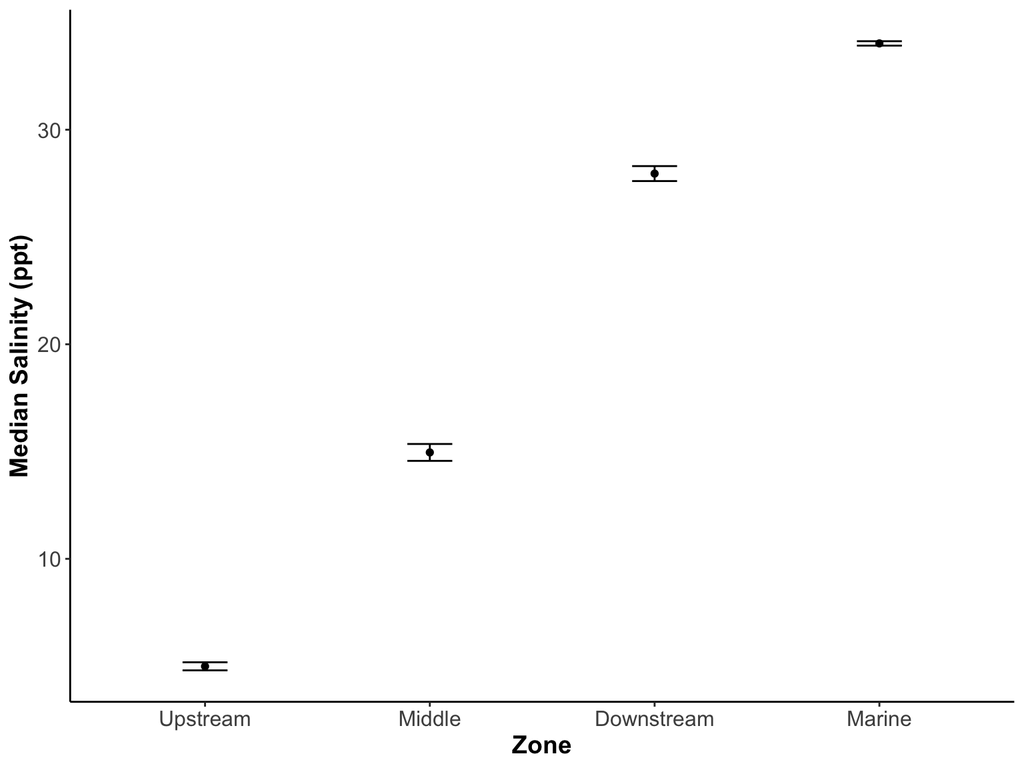

Figure 1. Median Salinity by Zone with Standard Deviation Error Bars

```r
# Create a figure theme to use for all figures for consistency and professionalism
marine_theme <- theme_classic() +
theme(
text = element_text(size = 14, colour = "black"),
axis.title = element_text(size = 14, face = "bold"),
axis.text = element_text(size = 12),
plot.title = element_text(size = 16, face = "bold"),
plot.subtitle = element_text(size = 13),
legend.title = element_text(size = 13),
legend.text = element_text(size = 12)
)

# Visualize
sal_sum |>
  ggplot(aes(x = zone, y = median_salinity)) +
  geom_point() +
  geom_errorbar(aes(ymin = median_salinity - sd_salinity, ymax = median_salinity + sd_salinity), width = 0.2) +
  marine_theme +
  labs(#title = "Median Salinity by Zone with Standard Deviation Error Bars",
       x = "Zone",
       y = "Median Salinity (ppt)")
```

## Turbidity

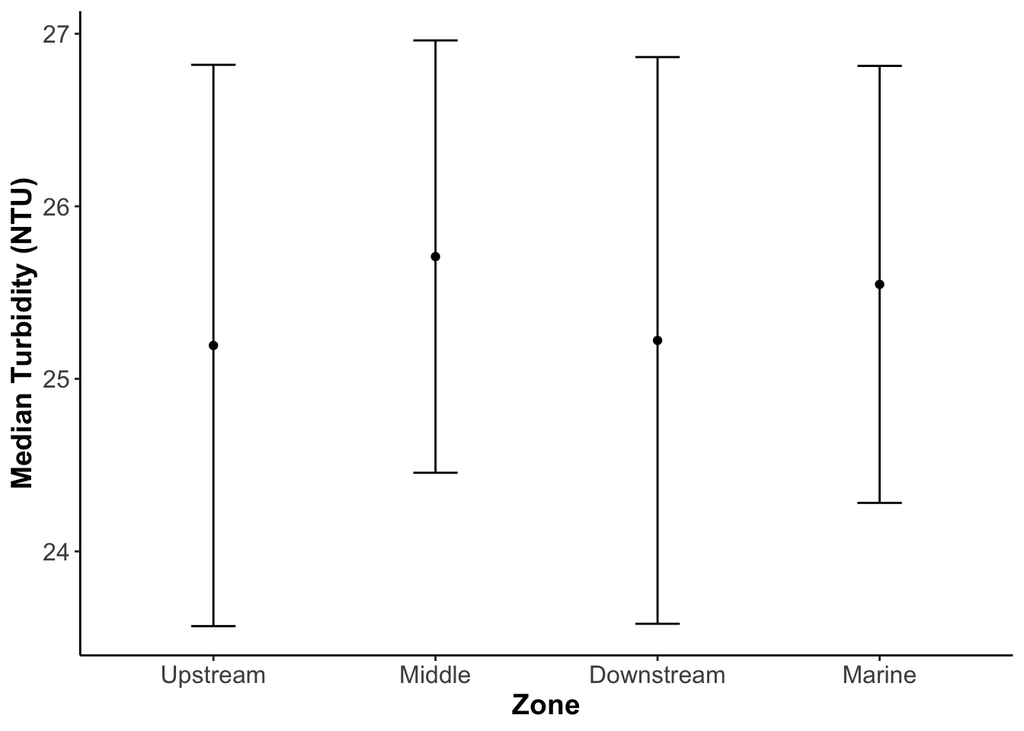

```r
turb_sum <-
  catch_data_final |>
  group_by(zone) |>
  summarise(
    sd_turbidity = sd(mean_turbidity, na.rm = TRUE),
    median_turbidity = median(mean_turbidity, na.rm = TRUE),
    mean_turbidity = mean(mean_turbidity, na.rm = TRUE),
    .groups = "drop"
  )

#| fig-cap: "Figure 2. Median Turbidity by Zone with Standard Deviation Error Bars"
#| subtitle: "Data from May 2026, Ross River Estuary System, Townsville, QLD, Australia"
#| fig-height: 6
#| fig-width: 8
turb_sum |>
  ggplot(aes(x = zone, y = median_turbidity)) +
  geom_point() +
  geom_errorbar(aes(ymin = median_turbidity - sd_turbidity, ymax = median_turbidity + sd_turbidity), width = 0.2) +
  marine_theme +
  labs(
       x = "Zone",
       y = "Median Turbidity (NTU)")
```

## Temperature

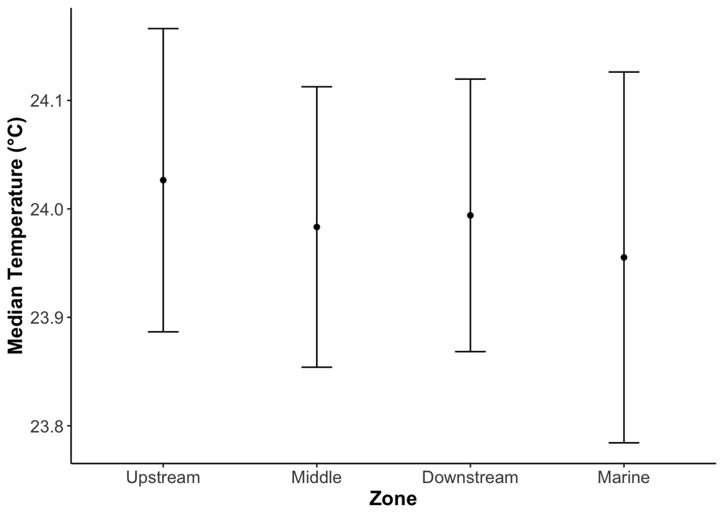

```r
temp_sum <-
  catch_data_final |>
  group_by(zone) |>
  summarise(
    sd_temperature = sd(mean_temp, na.rm = TRUE),
    median_temperature = median(mean_temp, na.rm = TRUE),
    mean_temperature = mean(mean_temp, na.rm = TRUE),
    .groups = "drop"
  )

#| fig-cap: "Figure 3. Median Temperature by Zone with Standard Deviation Error Bars"
#| subtitle: "Data from May 2026, Ross River Estuary System, Townsville, QLD, Australia"
#| fig-height: 6
#| fig-width: 8
temp_sum |>
  ggplot(aes(x = zone, y = median_temperature)) +
  geom_point() +
  geom_errorbar(aes(ymin = median_temperature - sd_temperature, ymax = median_temperature + sd_temperature), width = 0.2) +
  marine_theme +
  labs(
       x = "Zone",
       y = "Median Temperature (°C)")
```

### Interpretation

Because temperature and turbidity are not as strongly differentiated across the zones as salinity, I will focus on salinity as my main environmental variable of interest in my subsequent analyses and visualisations (though I will keep in mind the differences in turbidity and temperature across the zones, which could also be influencing fish abundance patterns).

# Fish abundance and summary stats

```r
Final_stats <- catch_data_final |>
  group_by(zone, scientific_name) |>
  summarise(
    mean_catch = mean(count),
    sd_catch = sd(count),
    sem_catch = sd(count) / sqrt(n()),
    mean_salinity = mean(mean_salinity),
    sd_salinity = sd(mean_salinity),
    .groups = "drop"
  )
Final_stats
```

```
# A tibble: 16 × 7
   zone  scientific_name mean_catch sd_catch sem_catch mean_salinity sd_salinity
   <fct> <chr>                <dbl>    <dbl>     <dbl>         <dbl>       <dbl>
 1 Upst… Acanthopagrus …       2.57    1.65      0.302          4.99          NA
 2 Upst… Lates calcarif…       4.8     1.69      0.309          4.99          NA
 3 Upst… Lutjanus argen…       1.9     1.16      0.211          4.99          NA
 4 Upst… Platycephalus …       2.3     1.82      0.333          4.99          NA
 5 Midd… Acanthopagrus …       2.23    1.57      0.286         14.9           NA
 6 Midd… Lates calcarif…       2.2     1.32      0.242         14.9           NA
 7 Midd… Lutjanus argen…       1.97    1.13      0.206         14.9           NA
 8 Midd… Platycephalus …       1.97    1.45      0.265         14.9           NA
 9 Down… Acanthopagrus …       2       1.51      0.275         28.0           NA
10 Down… Lates calcarif…       1.6     1.40      0.256         28.0           NA
11 Down… Lutjanus argen…       2       1.64      0.299         28.0           NA
12 Down… Platycephalus …       2.1     0.960     0.175         28.0           NA
13 Mari… Acanthopagrus …       2.33    1.88      0.344         34.0           NA
14 Mari… Lates calcarif…       1.57    1.36      0.248         34.0           NA
15 Mari… Lutjanus argen…       1.5     1.14      0.208         34.0           NA
16 Mari… Platycephalus …       5.67    1.30      0.237         34.0           NA
```

# Final Figure

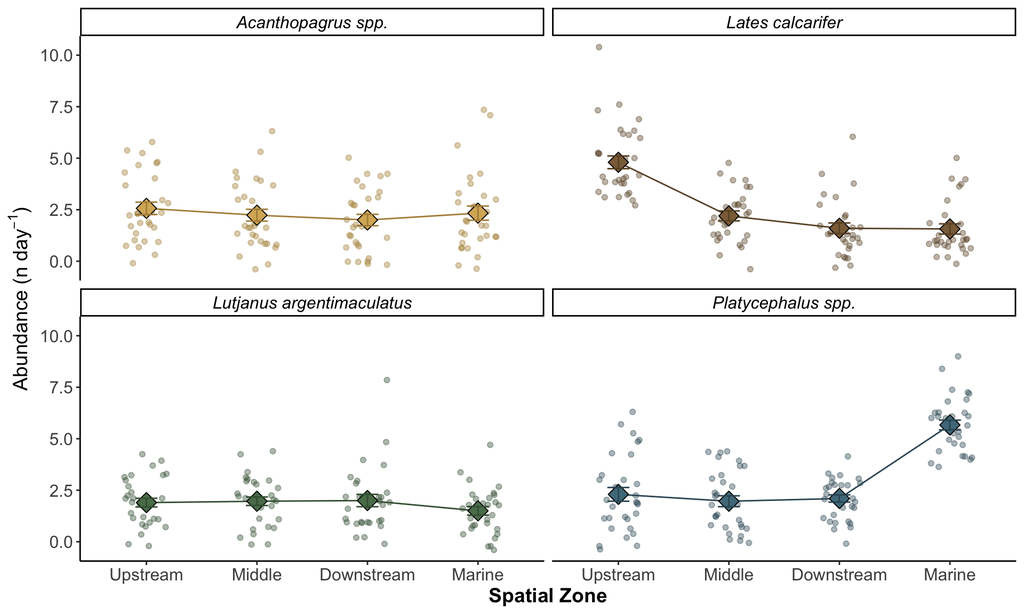

```r
earth_cols <- c(
"#D8B365", # sand
"#8C6D46", # brown
"#5A7D5A", # sage
"#4F7A8A" # muted blue-grey
)

earth_cols_dark <- c(
"#B08E45",
"#6B5231",
"#416041",
"#365765"
)

Final_stats |>
  ggplot(aes(x = zone,
             y = mean_catch,
             fill = scientific_name,
             colour = scientific_name)) +
  geom_line(group = 1) +
  # add in points from master data
  geom_point(
    data = catch_data_final,
    aes(x = zone,
        y = count,
        colour = scientific_name),
    position = position_jitter(width = 0.2),
    alpha = 0.4,
    size = 1.5,
    inherit.aes = FALSE) +
  geom_point(
    position = "dodge",
    size = 5,
    pch = 23,
    colour = "black") +
  scale_fill_manual(values = earth_cols) +
  scale_colour_manual(values = earth_cols_dark) +
  # SE pretty narrow, potentially not worth plotting but let's viewer see that included
  geom_errorbar(aes(ymin = mean_catch - sem_catch, ymax = mean_catch + sem_catch),
                position = position_dodge(0.9), width = 0.2) +
  facet_wrap(~ scientific_name, scales = "fixed") +
  marine_theme +
  theme(
    strip.text = element_text(face = "italic", size = 12, colour = "black"), # spp names in italic
   # legend.position = "bottom"
    legend.position = "none" # legend unnecessary
  ) +
  labs(
    x = "Spatial Zone",
    # scientific label for y axis of n day -1 use regex to get superscript
    y = expression("Abundance (n day"^-1*")"),
  #  y = "Daily abundance (n day^-1)"
    y = "Abundance (per day)"
  )
```

```r
write_csv(
  catch_data_final,
  here::here(
    "outputs",
    "workshop_02_clean_estuary_master.csv"
  )
)

write_csv(
  Final_stats,
  here::here(
    "outputs",
    "workshop_02_fish_salinity_summary.csv"
  )
)

fish_salinity_plot <- Final_stats |>
  ggplot(
    aes(
      x = zone,
      y = mean_catch,
      group = scientific_name
    )
  ) +
  # remaining layers
  NULL
```